# **Data Description**

**The Street View House Numbers (SVHN) Dataset**

SVHN is a real-world image dataset for developing machine learning and object recognition algorithms with minimal requirement on data formatting but comes from a significantly harder, unsolved, real world problem (recognizing digits and numbers in natural scene images). SVHN is obtained from house numbers in Google Street View images.

# Import the necessary libraries

```python
import h5py
import numpy as np
import matplotlib.pyplot as plt
from google.colab import drive
from tensorflow.keras.utils import to_categorical
from tensorflow.keras.models import Sequential
from tensorflow.keras.layers import Activation, Dense, BatchNormalization, Dropout
from tensorflow.keras import optimizers

%matplotlib inline

from numpy.random import seed

# Ignore the warnings
import warnings
warnings.filterwarnings("ignore")
```

# Load Dataset

### Import Drive from Google Colab

```python
drive.mount('/content/drive/')
```

### Access datafile in read mode

```python
seed(42)
h5f = h5py.File('/content/drive/My Drive/Colab Notebooks/GL-AIML/Neural Network and Deep Learning/Project - Neural Networks Classification/SVHN_single_grey1.h5', 'r');
```

```python
h5f.keys()
```

```
<KeysViewHDF5 ['X_test', 'X_train', 'X_val', 'y_test', 'y_train', 'y_val']>
```

### Read data into variables

```python
#Load the training, testing, and validation data
X_train = h5f['X_train'][:]
X_test  = h5f['X_test'][:]
X_val   = h5f['X_val'][:]
y_train = h5f['y_train'][:]
y_test  = h5f['y_test'][:]
y_val   = h5f['y_val'][:]

h5f.close()
```

### Printing the shape and data type of training, testing, and validation data

```python
print(f"Training feature shape {X_train.shape}\n")
print(f"Training target shape {y_train.shape}\n")
print(f"Validation feature shape {X_val.shape}\n")
print(f"Validation target shape {y_val.shape}\n")
print(f"Testing feature shape {X_test.shape}\n")
print(f"Testing target shape {y_test.shape}\n")
```

```
Training feature shape (42000, 32, 32)

Training target shape (42000,)

Validation feature shape (60000, 32, 32)

Validation target shape (60000,)

Testing feature shape (18000, 32, 32)

Testing target shape (18000,)
```

### Visualizing some images and their labels in the train dataset

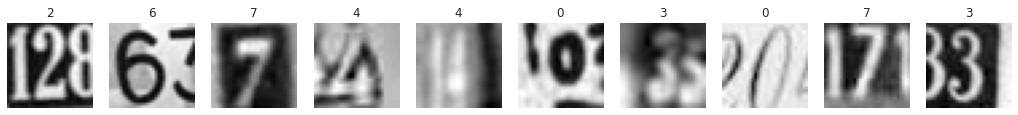

```python
plt.figure(figsize=(18, 2))
for i in range(10):
    plt.subplot(1, 10, i+1)
    plt.imshow(X_train[i],cmap='gray')
    plt.title(y_train[i])
    plt.axis('off')
plt.show()
```

### Visualizing the first 10 images and their labels in the validation dataset

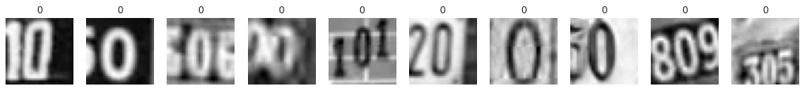

```python
plt.figure(figsize=(18, 2))
for i in range(10):
    plt.subplot(1, 10, i+1)
    plt.imshow(X_val[i],cmap='gray')
    plt.title(y_val[i])
    plt.axis('off')
plt.show()
```

### Visualizing the first 10 images and their labels in the test dataset

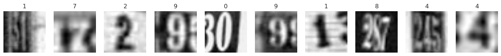

```python
plt.figure(figsize=(18, 2))
for i in range(10):
    plt.subplot(1, 10, i+1)
    plt.imshow(X_test[i],cmap='gray')
    plt.title(y_test[i])
    plt.axis('off')
plt.show()
```

```python
np.unique(y_train)
```

```
array([0, 1, 2, 3, 4, 5, 6, 7, 8, 9], dtype=uint8)
```

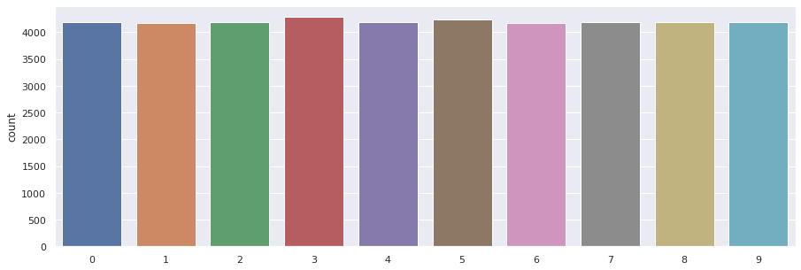

```python
import seaborn as sns
plt.figure(figsize=(15, 5))
sns.set(style="darkgrid")
ax = sns.countplot(x=y_train)
```

# Data Pre-processing

### Reshape the features from 32×32 into a single dimensional array of 1024 features in total.

```python
# reshaping X data: (n, 32, 32) => (n, 1024)
X_train = X_train.reshape((X_train.shape[0], -1))
X_test  = X_test.reshape((X_test.shape[0], -1))
X_val   = X_val.reshape((X_val.shape[0], -1))
```

```python
print(f"Training feature shape {X_train.shape}\n")
print(f"Validation feature shape {X_val.shape}\n")
print(f"Test feature shape {X_test.shape}\n")
```

```
Training feature shape (42000, 1024)

Validation feature shape (60000, 1024)

Test feature shape (18000, 1024)
```

### Checking the proportion of each class in the target variable to ensure there is no imbalance in the ground truth values.

```python
for i in range(0,10):
  print("Label: {0} | Value % = {1}".format( i, (y_train[y_train == i].size / y_train.size)*100) )
```

```
Label: 0 | Value % = 9.966666666666667
Label: 1 | Value % = 9.933333333333334
Label: 2 | Value % = 9.992857142857142
Label: 3 | Value % = 10.192857142857143
Label: 4 | Value % = 9.971428571428572
Label: 5 | Value % = 10.076190476190476
Label: 6 | Value % = 9.923809523809524
Label: 7 | Value % = 9.980952380952381
Label: 8 | Value % = 9.971428571428572
Label: 9 | Value % = 9.99047619047619
```

It looks good.

### One-hot encode the class vector

- convert class vectors (integers) to binary class matrix
- convert y_train, y_val and y_test
- number of classes: 10
- we are doing this to use categorical_crossentropy as loss

```python
# converting y data into categorical (one-hot encoding)
y_train = to_categorical(y_train, num_classes=10)
y_test  = to_categorical(y_test, num_classes=10)
y_val   = to_categorical(y_val, num_classes=10)
```

```python
print(f"Y training shape: {y_train.shape}\n")
print(f"Y validation shape: {y_val.shape}\n")
print(f"Y testing shape: {y_test.shape}\n")
```

```
Y training shape: (42000, 10)

Y validation shape: (60000, 10)

Y testing shape: (18000, 10)
```

```python
print(X_train.shape, X_test.shape,X_val.shape, y_train.shape, y_test.shape,y_val.shape)
```

```
(42000, 1024) (18000, 1024) (60000, 1024) (42000, 10) (18000, 10) (60000, 10)
```

# Implementing basic NN model

```python
## Initialize the Artificial Neural Network Classifier
model = Sequential()
```

```python
# Input layer
# adding input layer with activation function relu
model.add(Dense(512, kernel_initializer='he_normal',input_shape = (1024, )))
model.add(Activation('relu'))

# adding first hidden layer with activation function relu
model.add(Dense(256, kernel_initializer="he_normal"))
model.add(Activation('relu'))

# adding second hidden layer with activation function relu
model.add(Dense(128, kernel_initializer="he_normal"))
model.add(Activation('relu'))

# adding third hidden layer with activation function relu
model.add(Dense(64, kernel_initializer="he_normal"))
model.add(Activation('relu'))

# adding fourth hidden layer with activation function relu
model.add(Dense(32, kernel_initializer="he_normal"))
model.add(Activation('relu'))

# Output Layer
# Adding output layer which is of 10 nodes (digits)
model.add(Dense(10))
model.add(Activation('softmax'))

model.summary()
```

```
Model: "sequential_7"
_________________________________________________________________
Layer (type)                 Output Shape              Param #
=================================================================
dense_42 (Dense)             (None, 512)               524800
_________________________________________________________________
activation_42 (Activation)   (None, 512)               0
_________________________________________________________________
dense_43 (Dense)             (None, 256)               131328
_________________________________________________________________
activation_43 (Activation)   (None, 256)               0
_________________________________________________________________
dense_44 (Dense)             (None, 128)               32896
_________________________________________________________________
activation_44 (Activation)   (None, 128)               0
_________________________________________________________________
dense_45 (Dense)             (None, 64)                8256
_________________________________________________________________
activation_45 (Activation)   (None, 64)                0
_________________________________________________________________
dense_46 (Dense)             (None, 32)                2080
_________________________________________________________________
activation_46 (Activation)   (None, 32)                0
_________________________________________________________________
dense_47 (Dense)             (None, 10)                330
_________________________________________________________________
activation_47 (Activation)   (None, 10)                0
=================================================================
Total params: 699,690
Trainable params: 699,690
Non-trainable params: 0
_________________________________________________________________
```

### Using adam optimizer and Categorical Crossentropy as loss function and Accuracy as the metric to monitor

```python
# compiling the ANN classifier
adam = optimizers.Adam(learning_rate = 0.01)
Lambda = 1e3
model.compile(optimizer = adam, loss = 'categorical_crossentropy', metrics = ['accuracy'])
```

```python
# Fitting the ANN to the Training data
history = model.fit(X_train, y_train, validation_data=(X_val,y_val),batch_size = 200, epochs = 10, verbose = 1)
```

# Batch Normalization

```python
def mlp_model():
    model = Sequential()

    # Input layer
    # adding input layer with activation function relu
    model.add(Dense(512, kernel_initializer='he_normal',input_shape = (1024, )))
    model.add(BatchNormalization()) # Adding BatchNormalization Layer
    model.add(Activation('relu'))

    # adding first hidden layer with activation function relu
    model.add(Dense(256, kernel_initializer="he_normal"))
    model.add(BatchNormalization()) # Adding BatchNormalization Layer
    model.add(Activation('relu'))

    # adding second hidden layer with activation function relu
    model.add(Dense(128, kernel_initializer="he_normal"))
    model.add(BatchNormalization()) # Adding BatchNormalization Layer
    model.add(Activation('relu'))

    # adding third hidden layer with activation function relu
    model.add(Dense(64, kernel_initializer="he_normal"))
    model.add(BatchNormalization()) # Adding BatchNormalization Layer
    model.add(Activation('relu'))

    # adding fourth hidden layer with activation function relu
    model.add(Dense(32, kernel_initializer="he_normal"))
    model.add(BatchNormalization()) # Adding BatchNormalization Layer
    model.add(Activation('relu'))

    # Output Layer
    # Adding output layer which is of 10 nodes (digits)
    model.add(Dense(10))
    model.add(Activation('softmax'))

    return model
```

```python
model = mlp_model()

model.summary()

#Setting the learning rate in sgd
adam = optimizers.Adam(learning_rate = 0.01)

# compiling the ANN classifier
model.compile(optimizer = adam, loss = 'categorical_crossentropy', metrics = ['accuracy'])

# Fitting the ANN to the Training data
history = model.fit(X_train, y_train, validation_data=(X_val,y_val),batch_size = 200, epochs = 100, verbose = 1)
```

```
Model: "sequential_8"
_________________________________________________________________
Layer (type)                 Output Shape              Param #
=================================================================
dense_48 (Dense)             (None, 512)               524800
_________________________________________________________________
batch_normalization_20 (Batc (None, 512)               2048
_________________________________________________________________
activation_48 (Activation)   (None, 512)               0
_________________________________________________________________
dense_49 (Dense)             (None, 256)               131328
_________________________________________________________________
batch_normalization_21 (Batc (None, 256)               1024
_________________________________________________________________
activation_49 (Activation)   (None, 256)               0
_________________________________________________________________
dense_50 (Dense)             (None, 128)               32896
_________________________________________________________________
batch_normalization_22 (Batc (None, 128)               512
_________________________________________________________________
activation_50 (Activation)   (None, 128)               0
_________________________________________________________________
dense_51 (Dense)             (None, 64)                8256
_________________________________________________________________
batch_normalization_23 (Batc (None, 64)                256
_________________________________________________________________
activation_51 (Activation)   (None, 64)                0
_________________________________________________________________
dense_52 (Dense)             (None, 32)                2080
_________________________________________________________________
batch_normalization_24 (Batc (None, 32)                128
_________________________________________________________________
activation_52 (Activation)   (None, 32)                0
_________________________________________________________________
dense_53 (Dense)             (None, 10)                330
_________________________________________________________________
activation_53 (Activation)   (None, 10)                0
=================================================================
Total params: 703,658
Trainable params: 701,674
Non-trainable params: 1,984
_________________________________________________________________
```

```python
# Model evaluation
scores = model.evaluate(X_test, y_test, verbose=0)
print("Test Accuracy: %.2f%%" % (scores[1]*100))
```

```
Test Accuracy: 80.65%
```

#### Predicting the digits using NN classifier on test data

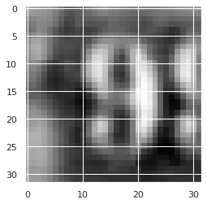

```python
#Showing the image
plt.imshow(X_test[5].reshape(32,32),cmap='gray')
```

```python
y_pred_class = model.predict_classes(X_test)
```

```python
y_pred_class[5]
```

```
9
```

# Classification accuracy metrics

```python
y_test = np.argmax(y_test, axis=-1)
```

```python
from sklearn import metrics
print(metrics.accuracy_score(y_test, y_pred_class))
```

```
0.8065
```

```python
cm = metrics.confusion_matrix(y_test, y_pred_class)
cm
```

```
array([[1498,   76,   26,   17,   22,   13,   44,   41,   26,   51],
       [  25, 1523,   47,   30,   52,   10,   18,   85,   22,   16],
       [  22,   34, 1532,   36,   16,   13,   14,   77,   23,   36],
       [  26,   60,   64, 1285,   14,  117,   20,   58,   46,   29],
       [  20,   64,   53,   21, 1538,   10,   38,   25,   15,   28],
       [  14,   24,   35,  100,   19, 1390,   68,   18,   50,   50],
       [  44,   44,   37,   34,   41,   90, 1406,   17,  102,   17],
       [  16,   55,   60,   14,   11,    4,   16, 1609,    7,   16],
       [  40,   65,   55,   60,   31,   49,   77,   26, 1353,   56],
       [  63,   56,   64,   32,   49,   47,   19,   56,   35, 1383]])
```

```python
from sklearn.metrics import classification_report
```

```python
print (classification_report(y_test, y_pred_class))
```

```
              precision    recall  f1-score   support

           0       0.85      0.83      0.84      1814
           1       0.76      0.83      0.80      1828
           2       0.78      0.85      0.81      1803
           3       0.79      0.75      0.77      1719
           4       0.86      0.85      0.85      1812
           5       0.80      0.79      0.79      1768
           6       0.82      0.77      0.79      1832
           7       0.80      0.89      0.84      1808
           8       0.81      0.75      0.78      1812
           9       0.82      0.77      0.79      1804

    accuracy                           0.81     18000
   macro avg       0.81      0.81      0.81     18000
weighted avg       0.81      0.81      0.81     18000
```

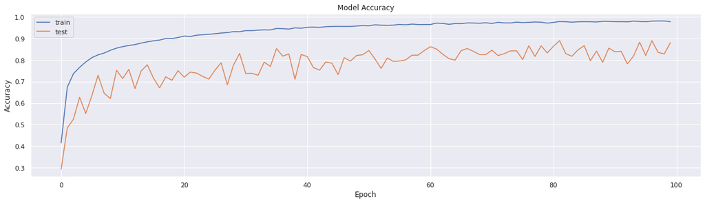

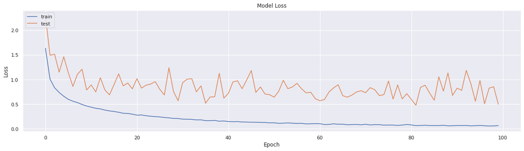

```python
# summarize history for accuracy
plt.figure(figsize=(20, 5))
plt.plot(history.history['accuracy'])
plt.plot(history.history['val_accuracy'])
plt.title('Model Accuracy')
plt.ylabel('Accuracy')
plt.xlabel('Epoch')
plt.legend(['train', 'test'], loc='upper left')
plt.show()

# summarize history for loss
plt.figure(figsize=(20, 5))
plt.plot(history.history['loss'])
plt.plot(history.history['val_loss'])
plt.title('Model Loss')
plt.ylabel('Loss')
plt.xlabel('Epoch')
plt.legend(['train', 'test'], loc='upper left')
plt.show()
```